# Kolleg Europa - Social Network Analysis

Datenauswertung Reisediplomatie-Netzwerk

Stefan Haussner

08.07.2019

```r
load("C:/OwnCloud/SH/Workshops_Talks/KollegEuropa_Studienstiftung_Netzwerkanalyse_Prag/R/network_analysis_KollegEuropa/data/data_preprocessed.Rdata")
#load("D:/KollegEuropa_Studienstiftung_Netzwerkanalyse_Prag/R/network_analysis_KollegEuropa/data/data_preprocessed.Rdata")
```

Grundsätzlich sieht das Reisediplomatie-Netzwerk bereits so aus. Limitations bzw. offene Fragen finden sich im `script_datawrangling.Rmd`. Größere Abbildungen liegen in “outputs”.

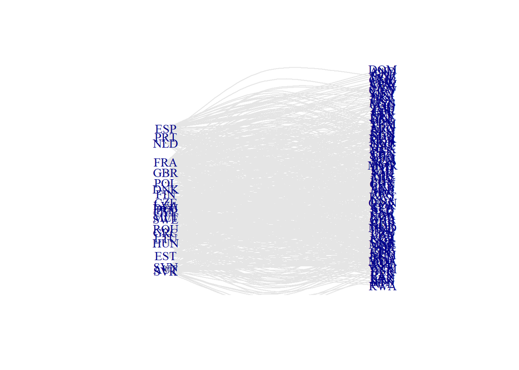

```r
LO <- layout_as_bipartite(rd_igraph)

# Variante 1:


plot.igraph(rd_igraph,
            vertex.color = V(rd_igraph)$type,
            layout=LO[,2:1],
            vertex.size = 0,
            #vertex.label.color = V(rd_igraph)$color,
            edge.color = "grey90")
```

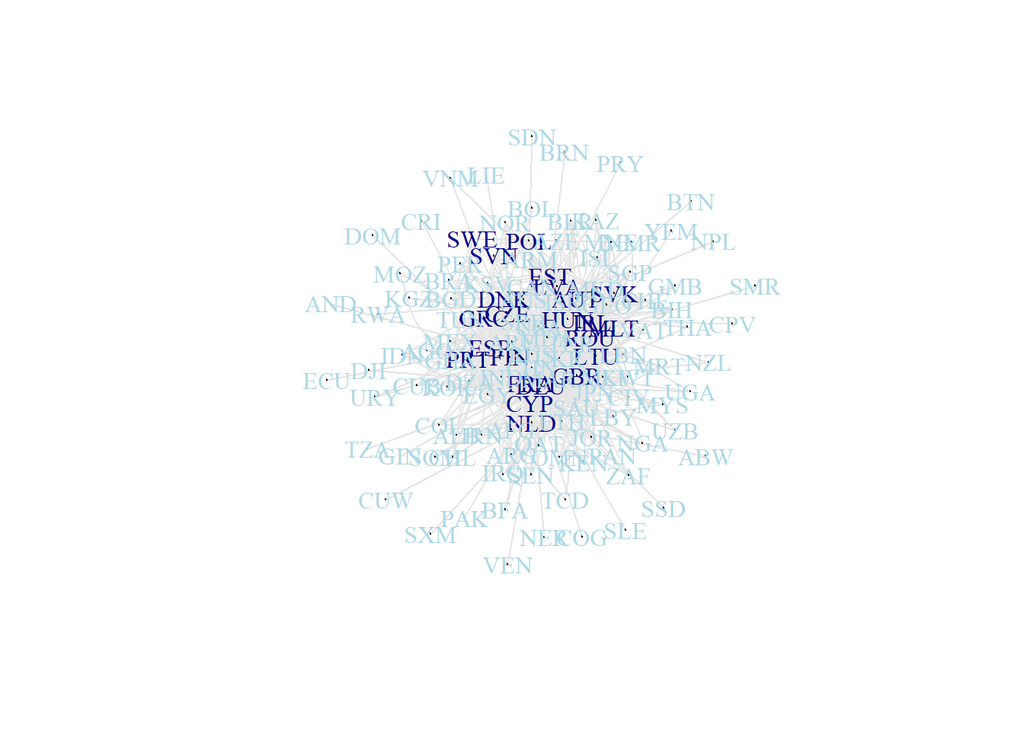

```r
# Variante 2:

plot.igraph(rd_igraph,
            vertex.color = V(rd_igraph)$type,
            layout=layout_with_lgl,
            vertex.size = 0,
            vertex.label.color = V(rd_igraph)$color,
            edge.color = "grey90")
```

```r
#rd_igraph <- subgraph.edges(rd_igraph, eids = which(E(rd_igraph)$year == 2019))
```

# Analyse des Two-Mode-Netzwerks

Es gibt verschiedene Ansätze für die Analyse von Zugehörigkeitsdaten, ohne die Umwandlung in `Co-Affiliation-Netze` (Projections). Da Zugehörigkeitsgraphen auch Graphen sind, liegt der naheliegende Ansatz darin, einfach alle Standardalgorithmen und -techniken des Netzwerkanalyse-Toolkits zu verwenden, die für normale Netze im Allgemeinen gelten.

Dabei gehen wir entweder davon aus, dass die spezielle Natur von Affiliationsnetzen die Techniken nicht beeinflusst, oder wir können vorgeben, dass Bindungen innerhalb von Knotensätzen aufgetreten sein könnten und einfach nicht aufgetreten sind. Dieser Ansatz funktioniert für eine kleine Klasse von Methoden, jedoch keineswegs für alle.

Ein alternativer Ansatz besteht darin, neue Metriken und Algorithmen zu entwickeln, die speziell für den TwoMode-Fall designed wurden. Das hört sich nach viel mehr Arbeit an, aber in der Praxis ist es oft möglich, Metriken anzupassen, die für allgemeine Diagramme ausgelegt sind, indem einfach eine entsprechende Post-hoc-Normalisierung angewendet wird. Besonders bei Zentralitätsmaßen ist das meist der bessere Weg.[^1]

Im Degree-Fall ist es nicht sinnvoll, den einfachen Grad (Anzahl aller Verbindungen des Knotens) zu zählen und daraus die Dichte zu errechnen. Denn zwischen den Knoten einer Gruppe können ja gar keine Verbindungen bestehen. Eine sinnvolle Änderung ist es also, wenn die Dichte auf der Grundlage der Verbindungen besteht, die der Knoten mit der Gruppe des anderen Typs aufweist.

```r
density_bipartite <- function(graph) {
  if (is.directed(graph)) {
    ecount(graph) / sum(V(graph)$type) / sum(!V(graph)$type) / 2.0}
  else {
    ecount(graph) / sum(V(graph)$type) / sum(!V(graph)$type)
  }
}

edge_density(rd_igraph)
```

```
## [1] 0.07874016
```

```r
density_bipartite(rd_igraph)
```

```
## [1] 0.2633779
```

Auch bei der Closeness-Zentralität bietet sich eine Anpassung an. Diese wurde an dieser Stelle in ein externes Script ausgelagert (`bipartite_closeness_centrality.R`) und kann dort bei Bedarf nachvollzogen werden.

> Erinnerung `Closeness`: mittlere Entfernung von einem Scheitelpunkt zu anderen Scheitelpunkten.

```r
source("bipartite_closeness_centrality.R")

#bipartite_closeness_centrality(rd_igraph)

bipartite_closeness_centrality(rd_igraph) %>% unlist() %>% unname() %>% round(3) %>% tbl_df() %>%
  mutate(name = V(rd_igraph)$name,
         type = case_when(V(rd_igraph)$type == TRUE ~ "eu",
                          TRUE ~ "non-eu")) %>%
  select(name, closeness_centrality = value, type) %>%
  arrange(type, -closeness_centrality) %>%
  datatable(options = list(pageLength = 23))
```

|  | name | closeness_centrality | type |
| --- | --- | --- | --- |
| 1 | CYP | 0.63 | eu |
| 2 | FIN | 0.583 | eu |
| 3 | DNK | 0.544 | eu |
| 4 | HUN | 0.525 | eu |
| 5 | SVN | 0.5 | eu |
| 6 | DEU | 0.49 | eu |
| 7 | CZE | 0.49 | eu |
| 8 | EST | 0.474 | eu |
| 9 | LVA | 0.471 | eu |
| 10 | MLT | 0.471 | eu |

[output cut: 117 more lines]

Gleiches gilt für die Betweenness-Zentralität.

> Erinnerung `Betweenness`: Ausmaß, in dem ein Knoten auf Pfaden zwischen anderen Knoten liegt.

```r
source("bipartite_betweenness_centrality.R")

#bipartite_betweenness_centrality(rd_igraph)

bipartite_betweenness_centrality(rd_igraph) %>% unlist() %>% unname() %>% round(3) %>% tbl_df %>%
  mutate(name = V(rd_igraph)$name,
         type = case_when(V(rd_igraph)$type == TRUE ~ "eu",
                          TRUE ~ "non-eu")) %>%
  select(name, betweenness_centrality = value, type) %>%
  arrange(type, -betweenness_centrality) %>%
  datatable(options = list(pageLength = 23))
```

|  | name | betweenness_centrality | type |
| --- | --- | --- | --- |
| 1 | FIN | 0.256 | eu |
| 2 | DNK | 0.19 | eu |
| 3 | CYP | 0.175 | eu |
| 4 | HUN | 0.138 | eu |
| 5 | SVN | 0.113 | eu |
| 6 | CZE | 0.083 | eu |
| 7 | MLT | 0.076 | eu |
| 8 | NLD | 0.063 | eu |
| 9 | DEU | 0.059 | eu |
| 10 | EST | 0.043 | eu |

[output cut: 117 more lines]

# Analyse der One-Mode-Projektionen

Die gemeinsame Untersuchung beider Knotentypen in einer Two-Mode-Netzwerkgrafik ist häufig der erste Schritt beim Studium eines Zugehörigkeitsnetzwerks. Es ist jedoch auch sinnvoll die `One-Mode-Projektionen` des Netzwerks zu untersuchen. Die Funktion `bipartite.projection` gibt eine Liste von zwei igraph-Netzwerkobjekten zurück. Das erste Netzwerk besteht aus direkten Verbindungen zwischen dem ersten Modus und das zweite Netzwerk zeigt die Verbindungen zwischen dem zweiten Modus. In unserem Fall also ein Netzwerk aller EU28-Länder und ein Netzwerk aller Gastgeberländer.

```r
rd_projection <- bipartite.projection(rd_igraph)
rd_projection
```

```
## $proj1
## IGRAPH 81d7cdd UNW- 104 3039 --
## + attr: name (v/c), color (v/c), weight (e/n)
## + edges from 81d7cdd (vertex names):
##  [1] USA--MEX USA--CHN USA--IDN USA--SGP USA--ISL USA--IND USA--GHA
##  [8] USA--RUS USA--UKR USA--GEO USA--DZA USA--EGY USA--TUN USA--SAU
## [15] USA--ARE USA--ARG USA--VAT USA--ISR USA--JOR USA--LBN USA--ARM
## [22] USA--AZE USA--SEN USA--NGA USA--MKD USA--TUR USA--JPN USA--MLI
## [29] USA--SRB USA--KSV USA--IRQ USA--KWT USA--SOM USA--ETH USA--LBY
## [36] USA--QAT USA--UGA USA--SSD USA--AFG USA--TZA USA--KOR USA--ALB
## [43] USA--SLE USA--BFA USA--PAK USA--CAN USA--MAR USA--BLR USA--BGD
## [50] USA--MDA USA--BRN USA--NOR USA--KAZ USA--CHE USA--VNM USA--AGO
## + ... omitted several edges
##
## $proj2
## IGRAPH 81d7cdd UNW- 23 251 --
## + attr: name (v/c), color (v/c), weight (e/n)
## + edges from 81d7cdd (vertex names):
##  [1] DNK--DEU DNK--EST DNK--FIN DNK--FRA DNK--GRC DNK--IRL DNK--LVA
##  [8] DNK--LTU DNK--NLD DNK--AUT DNK--POL DNK--PRT DNK--ROU DNK--SWE
## [15] DNK--SVK DNK--ESP DNK--CZE DNK--HUN DNK--GBR DNK--CYP DNK--MLT
## [22] DNK--SVN DEU--EST DEU--FIN DEU--FRA DEU--GRC DEU--IRL DEU--LVA
## [29] DEU--LTU DEU--NLD DEU--AUT DEU--POL DEU--PRT DEU--ROU DEU--SWE
## [36] DEU--SVK DEU--ESP DEU--CZE DEU--HUN DEU--GBR DEU--CYP DEU--MLT
## [43] DEU--SVN EST--FIN EST--FRA EST--GRC EST--IRL EST--LVA EST--LTU
## [50] EST--NLD EST--AUT EST--POL EST--PRT EST--ROU EST--SWE EST--SVK
## + ... omitted several edges
```

```r
rd_hosts <- rd_projection$proj1
rd_eu28 <- rd_projection$proj2

rd_eu28
```

```
## IGRAPH 81d7cdd UNW- 23 251 --
## + attr: name (v/c), color (v/c), weight (e/n)
## + edges from 81d7cdd (vertex names):
##  [1] DNK--DEU DNK--EST DNK--FIN DNK--FRA DNK--GRC DNK--IRL DNK--LVA
##  [8] DNK--LTU DNK--NLD DNK--AUT DNK--POL DNK--PRT DNK--ROU DNK--SWE
## [15] DNK--SVK DNK--ESP DNK--CZE DNK--HUN DNK--GBR DNK--CYP DNK--MLT
## [22] DNK--SVN DEU--EST DEU--FIN DEU--FRA DEU--GRC DEU--IRL DEU--LVA
## [29] DEU--LTU DEU--NLD DEU--AUT DEU--POL DEU--PRT DEU--ROU DEU--SWE
## [36] DEU--SVK DEU--ESP DEU--CZE DEU--HUN DEU--GBR DEU--CYP DEU--MLT
## [43] DEU--SVN EST--FIN EST--FRA EST--GRC EST--IRL EST--LVA EST--LTU
## [50] EST--NLD EST--AUT EST--POL EST--PRT EST--ROU EST--SWE EST--SVK
## + ... omitted several edges
```

```r
E(rd_eu28)$weight
```

```
##   [1]  27   6  13  28   6   8   5  12   8   9   4   5   3   2   7  11   7
##  [18]   9   9   4   5   2  49  67 141  58  69  27  61  25  63  18  33  45
##  [35]  12  43  39  39  63  95  37  27  13  15  25  15  14   9  25   6  17
##  [52]   6   5  19   4  17   9  11  24  16  13   4   7  48  22  34  12  22
##  [69]  13  24   7  19  13   8  15  21  20  19  34  12   8   4  35  37  20
##  [86]  37  34  37  10  29  28   9  18  62  28  48  84  24  25  10  28   7
## [103]  17  11  19   5  11  15   5  11   7  17  24  24   6  11   6  17  30
## [120]  17  19   8  22  25   8  17  11  29  22  45  12   6   1  15   7  12
## [137]   3   9  12   2   6   8  11   9  21   8   4   1  11  16   8   9  25
## [154]   3  19   9  21  23  33  15   9   5   2   2   2   9   7  14  14   5
## [171]  10   4   9   3   2   7   2   8   9   2   5  13  12   7  19   6   2
## [188]   3   6  11   3  12  13   9  21  27  10   7   8   2   2   5   4   4
## [205]   6   7   3   1  10   4   7  20  12   8  24   3   2  12  12  18  24
## [222]  20  12   1   2   2   4   4  10   1   3   9  18  13   6   3   1   5
## [239]   1   1   1  10  15  23   5  15  25   9  22  13  24
```

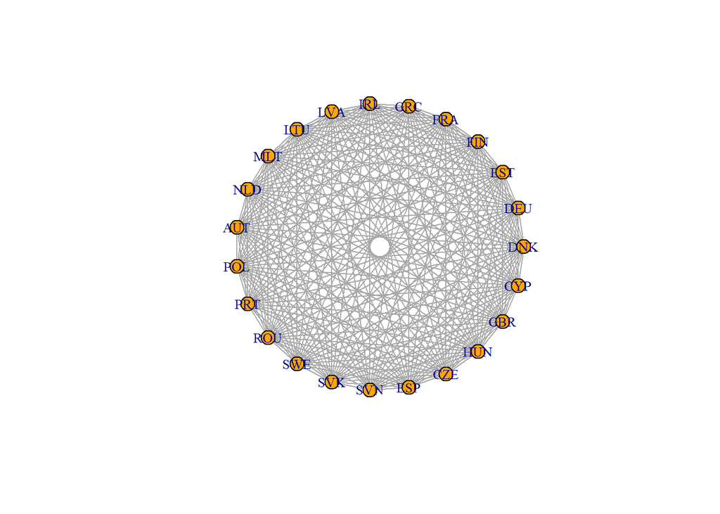

```r
plot.igraph(rd_eu28,
            vertex.label.cex = 0.8,
            vertex.size = 10,
            vertex.color = "orange",
            layout = layout_in_circle)
```

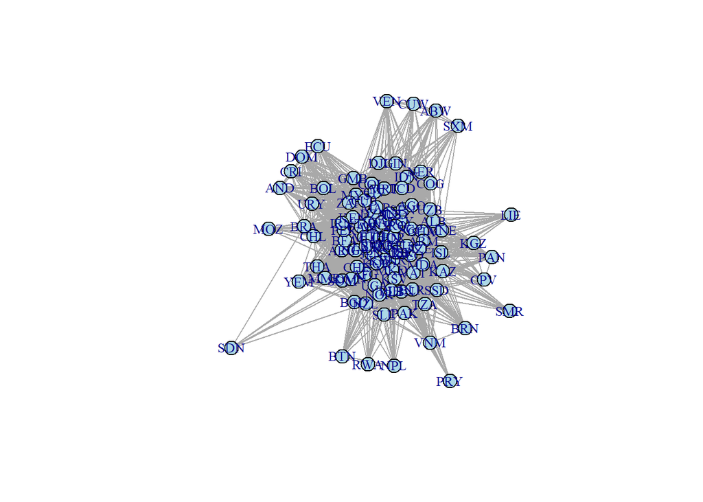

```r
plot.igraph(rd_hosts,
            vertex.label.cex = 0.8,
            vertex.size = 10,
            vertex.color = "lightblue")
```

# Analyse des EU28-Netzwerks

Das EU28-Netzwerk ist ein `Co-occurence-Netzwerk` (One-Mode-Projektion des ursprünglichen Reisediplomatienetzwerks). Zwei Länder der EU28 haben dann eine Verbindung, wenn sie das gleiche Gastland besucht haben. Das Netzwerk ist ein ungerichtetes Netzwerk.

## Distances and paths

```r
mean_distance(rd_eu28, directed=FALSE)
```

```
## [1] 1.007905
```

## edge density

```r
edge_density(rd_eu28)
```

```
## [1] 0.9920949
```

## Welche Länder sind im Netzwerk besonders auffallend?

Es ist intuitiv sinnvoll, dass ein Netzwerkmitglied, das mit vielen anderen Mitgliedern des Netzwerks verbunden ist, eine herausragende Position einnimmt. Für nicht gerichtete Netzwerke sprechen wir von Akteuren mit einer hohen Zentralität. Es gibt jedoch eine Reihe von Möglichkeiten, diese Art der Zentralität zu operationalisieren. Tatsächlich stehen in der Sozialen Netzwerkanalyse Dutzende von Zentralitätsstatistiken zur Verfügung.

### Degree centrality

> Erinnerung degree: Anzahl, wie viele Nachbarn ein Knoten hat.

```r
degree(rd_eu28)
```

```
## DNK DEU EST FIN FRA GRC IRL LVA LTU MLT NLD AUT POL PRT ROU SWE SVK SVN
##  22  22  22  22  22  22  22  22  22  22  22  22  22  21  22  21  22  20
## ESP CZE HUN GBR CYP
##  22  22  22  22  22
```

```r
r_degree <- degree(rd_eu28)

data.frame(r_degree) %>%
  datatable(options = list(pageLength = 23))
```

|  | r_degree |
| --- | --- |
| DNK | 22 |
| DEU | 22 |
| EST | 22 |
| FIN | 22 |
| FRA | 22 |
| GRC | 22 |
| IRL | 22 |
| LVA | 22 |
| LTU | 22 |
| MLT | 22 |

[output cut: 13 more lines]

### Closeness Centrality

> Erinnerung closeness: mittlere Entfernung von einem Scheitelpunkt zu anderen Scheitelpunkten

```r
r_closeness <- closeness(rd_eu28, weights = E(rd_eu28)$weight)
data.frame(r_closeness) %>%
  round(5) %>%
  datatable(options = list(pageLength = 23))
```

|  | r_closeness |
| --- | --- |
| DNK | 0.00901 |
| DEU | 0.00308 |
| EST | 0.00658 |
| FIN | 0.00633 |
| FRA | 0.00383 |
| GRC | 0.00571 |
| IRL | 0.01053 |
| LVA | 0.01042 |
| LTU | 0.00704 |
| MLT | 0.00917 |

[output cut: 13 more lines]

### Betweenness

> Erinnerung betweenness: Ausmaß, in dem ein Knoten auf Pfaden zwischen anderen Knoten liegt.

```r
r_betweenness <- igraph::betweenness(rd_eu28, weights = E(rd_eu28)$weight)
data.frame(r_betweenness) %>%
  round(5) %>%
  datatable(options = list(pageLength = 23))
```

|  | r_betweenness |
| --- | --- |
| DNK | 0 |
| DEU | 0 |
| EST | 0 |
| FIN | 0 |
| FRA | 0 |
| GRC | 0 |
| IRL | 0 |
| LVA | 0 |
| LTU | 0 |
| MLT | 8.48333 |

[output cut: 13 more lines]

### Eigenvector-Centrality

> Erinnerung eigenvector: Ein Knoten ist wichtig, wenn er mit anderen wichtigen Knoten verbunden ist.

```r
r_eigen <- eigen_centrality(rd_eu28, weights = E(rd_eu28)$weight)
data.frame(r_eigen$vector) %>%
  round(5) %>%
  datatable(options = list(pageLength = 23))
```

|  | r_eigen.vector |
| --- | --- |
| DNK | 0.21398 |
| DEU | 1 |
| EST | 0.33989 |
| FIN | 0.49233 |
| FRA | 0.84932 |
| GRC | 0.40189 |
| IRL | 0.51336 |
| LVA | 0.24303 |
| LTU | 0.45455 |
| MLT | 0.21211 |

[output cut: 13 more lines]

Alle Ergebnisse gesammelt und in sortierbarer Tabelle:

```r
results_df <- data.frame(r_degree,r_closeness, r_betweenness, r_eigen$vector) %>%
  rownames_to_column() %>% tbl_df() %>%
  mutate_if(is.numeric, round, 4) %>%
  arrange(rowname)

datatable(results_df, options = list(pageLength = 23))
```

|  | rowname | r_degree | r_closeness | r_betweenness | r_eigen.vector |
| --- | --- | --- | --- | --- | --- |
| 1 | AUT | 22 | 0.0075 | 0 | 0.4061 |
| 2 | CYP | 22 | 0.0111 | 13.8167 | 0.2652 |
| 3 | CZE | 22 | 0.0104 | 0 | 0.3414 |
| 4 | DEU | 22 | 0.0031 | 0 | 1 |
| 5 | DNK | 22 | 0.009 | 0 | 0.214 |
| 6 | ESP | 22 | 0.0108 | 0 | 0.3585 |
| 7 | EST | 22 | 0.0066 | 0 | 0.3399 |
| 8 | FIN | 22 | 0.0063 | 0 | 0.4923 |
| 9 | FRA | 22 | 0.0038 | 0 | 0.8493 |
| 10 | GBR | 22 | 0.0105 | 0 | 0.6608 |

[output cut: 13 more lines]

## Subgroups and communities

### Transitivität

> Die Transitivität misst die Wahrscheinlichkeit, dass die benachbarten Knoten eines Knoten miteinander verbunden sind. Dies wird manchmal auch als Clustering-Koeffizient bezeichnet.

```r
transitivity(rd_eu28)
```

```
## [1] 0.9923518
```

### Größte Clique

Macht in diesem Falle auch wenig Sinn.

```r
#cliques(rd_eu28) # list of cliques
largest_cliques(rd_eu28)
```

```
## [[1]]
## + 22/23 vertices, named, from 81d7cdd:
##  [1] DNK DEU EST FIN FRA GRC IRL LVA LTU MLT NLD AUT POL ROU SVK ESP CZE
## [18] HUN GBR CYP PRT SWE
```

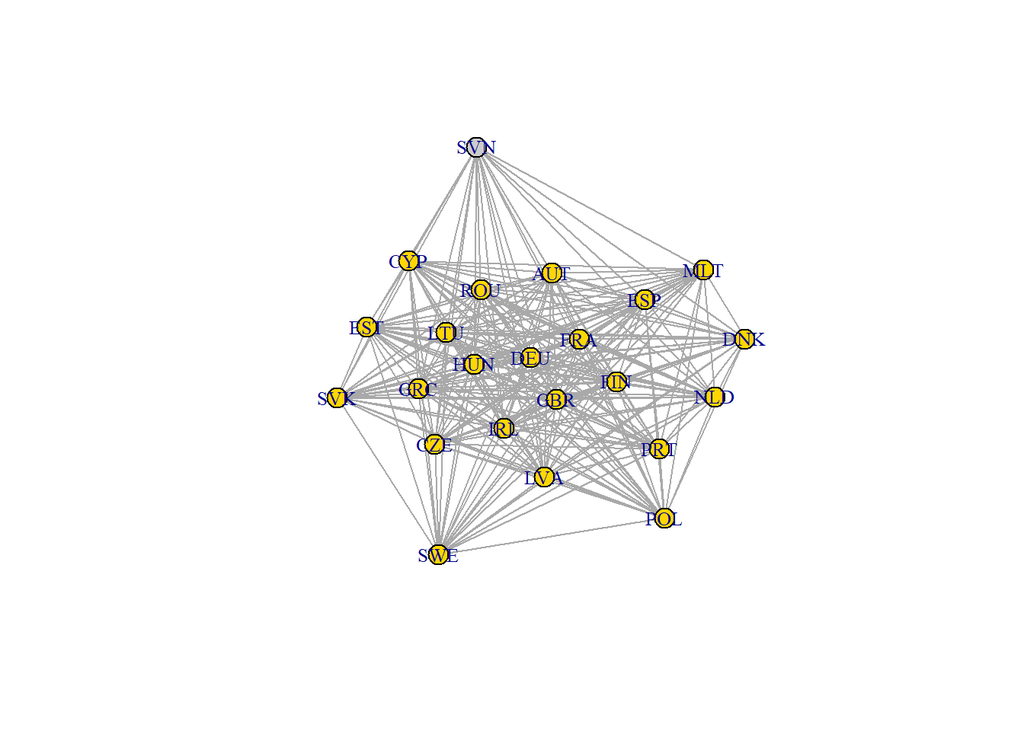

```r
vcol <- rep("grey80", vcount(rd_eu28))
vcol[unlist(largest_cliques(rd_eu28))] <- "gold"
plot(as.undirected(rd_eu28), vertex.label=V(rd_eu28)$name, vertex.color=vcol,
     vertex.label.cex = 0.8,
     vertex.size = 10)
```

### Community detection

Auch das ist schwierig, da beispielsweise bei der edge_betweenness nur ein Cluster rauskommt. Bei anderen k=2, was unterstreicht, wie schwer differenzierbar die Knoten sind.

```r
ceb <- cluster_edge_betweenness(rd_eu28, weights = E(rd_eu28)$weight)
```

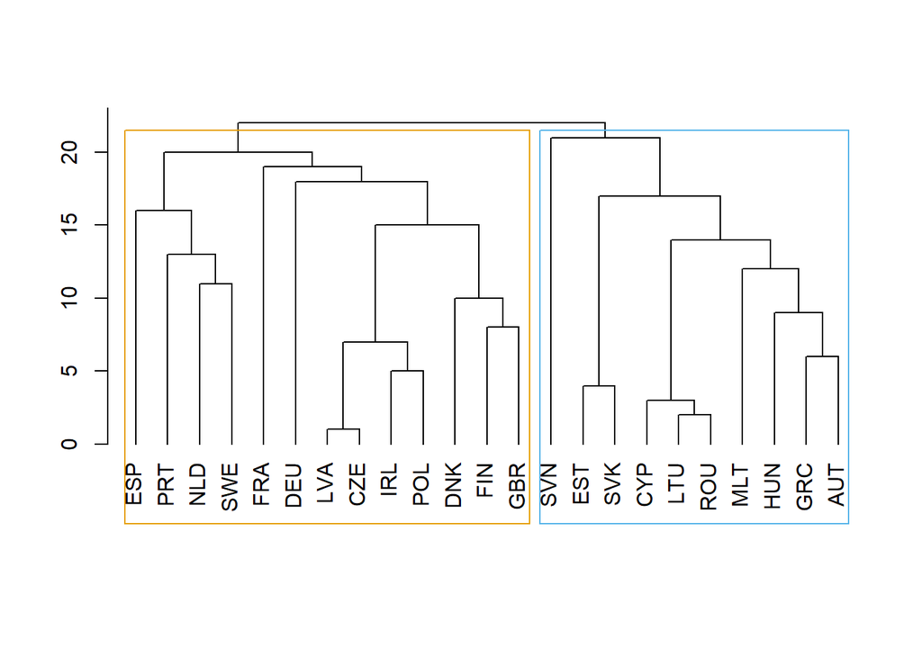

```r
cle <- cluster_leading_eigen(rd_eu28, weights = E(rd_eu28)$weight)

cop <- cluster_optimal(rd_eu28, weights = E(rd_eu28)$weight)

cluster_walktrap(rd_eu28, weights = E(rd_eu28)$weight) %>% dendPlot(mode = "hclust")
```

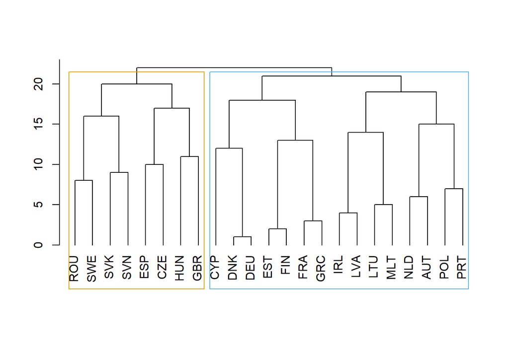

```r
#dendPlot(ceb, mode="hclust")
dendPlot(cle, mode="hclust")
```

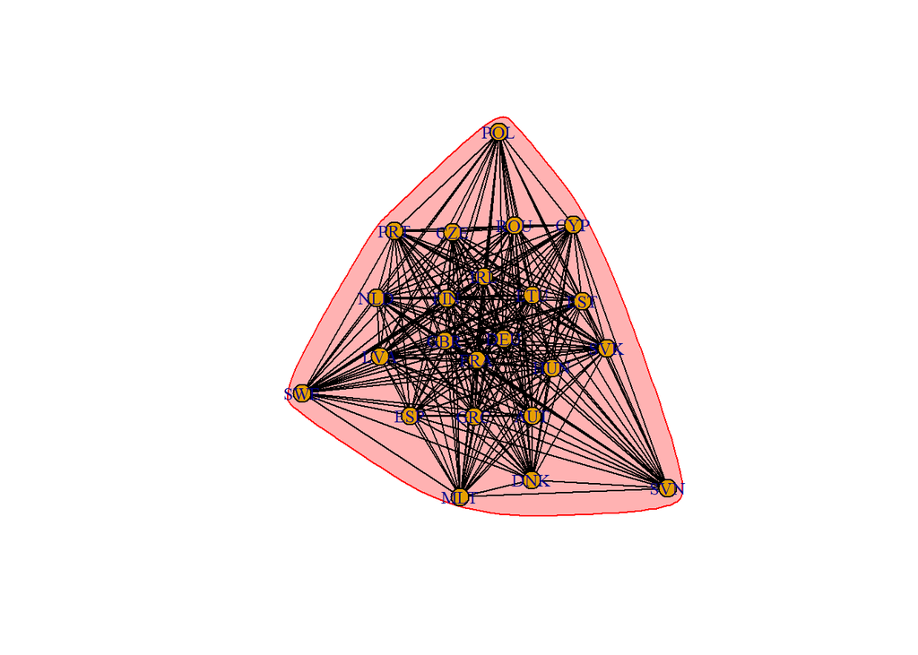

```r
plot(ceb,rd_eu28,
     vertex.label.cex = 0.8,
     vertex.size = 10)
```

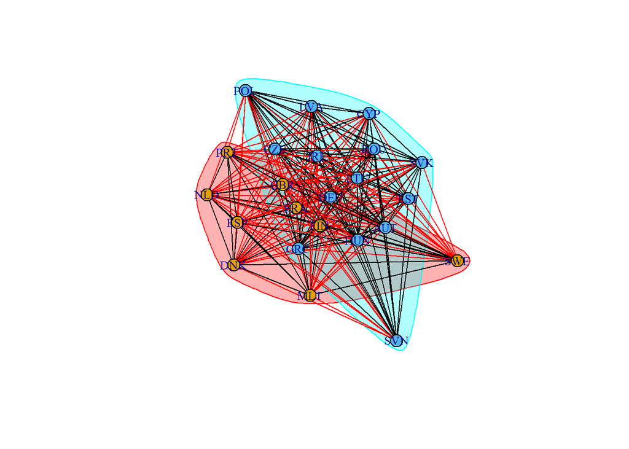

```r
plot(cle,rd_eu28,
     vertex.label.cex = 0.8,
     vertex.size = 10)
```

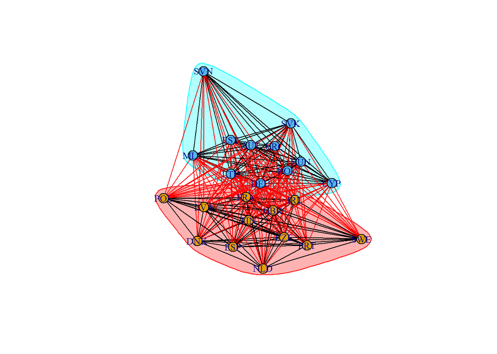

```r
plot(cop,rd_eu28,
     vertex.label.cex = 0.8,
     vertex.size = 10)
```

# Exponential Random Graph Models

Wie “besonders” sind unsere Projektionsnetzwerke, im Vergleich zu ähnlich aufgebauten Netzwerken?

```r
g_random <- vector('list',1000)

for(i in 1:1000){

  g_random[[i]] <- sample_gnp(n = gorder(rd_eu28),
                              p = closeness(rd_eu28, weights = E(rd_eu28)$weight, normalized = TRUE),
                              directed = FALSE)
}

# apply mean_distance on every graph
g_random_meandis <- unlist(lapply(g_random, mean_distance, directed = FALSE))

mean_distance(rd_eu28, directed = FALSE)
```

```
## [1] 1.007905
```

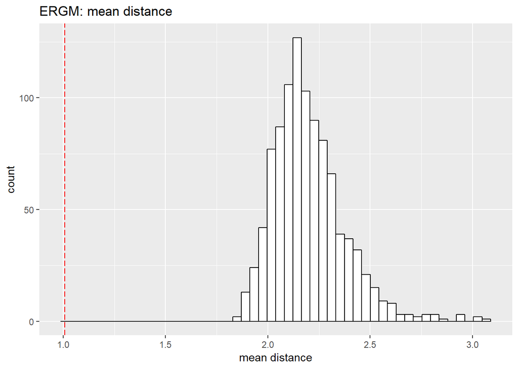

```r
# graphical comparison to original network
ggplot() +
  aes(g_random_meandis)+
  geom_histogram(bins = 50, colour="black", fill="white")+
  geom_vline(xintercept = mean_distance(rd_eu28, directed = FALSE), colour="red", linetype = "longdash")+
  labs(title = "ERGM: mean distance",
       x = "mean distance")
```

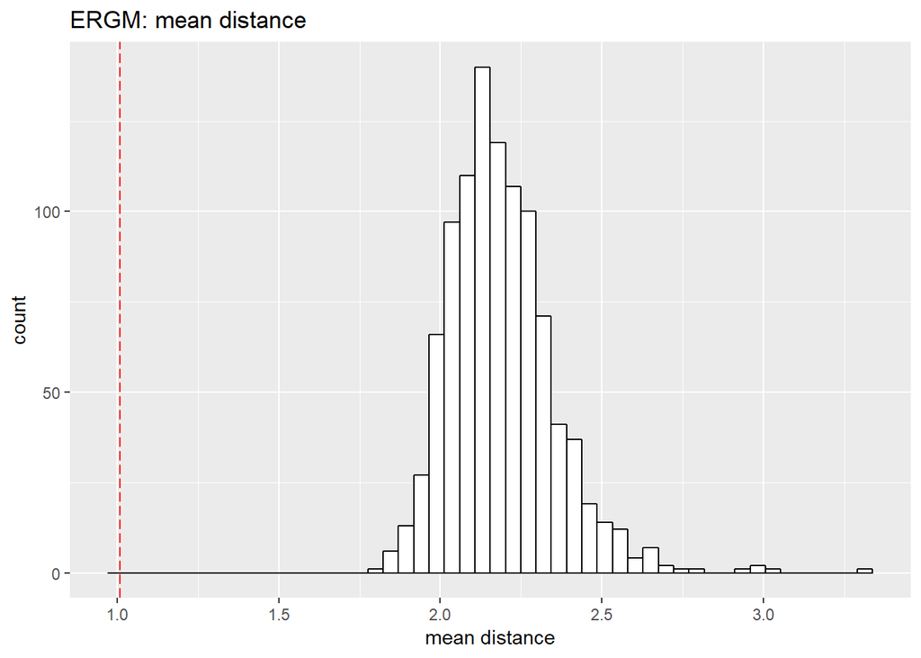

```r
g_random <- vector('list',1000)

for(i in 1:1000){

  g_random[[i]] <- sample_gnp(n = gorder(rd_eu28),
                              p = closeness(rd_eu28, weights = E(rd_eu28)$weight, normalized = TRUE),
                              directed = FALSE)
}

# apply mean_distance on every graph
g_random_meandis <- unlist(lapply(g_random, mean_distance, directed = FALSE))

g_random_transitivity <- unlist(lapply(g_random, transitivity))

ggplot() +
  aes(g_random_meandis)+
  geom_histogram(bins = 50, colour="black", fill="white")+
  geom_vline(xintercept = mean_distance(rd_eu28, directed = FALSE), colour="red", linetype = "longdash")+
  labs(title = "ERGM: mean distance",
       x = "mean distance")
```

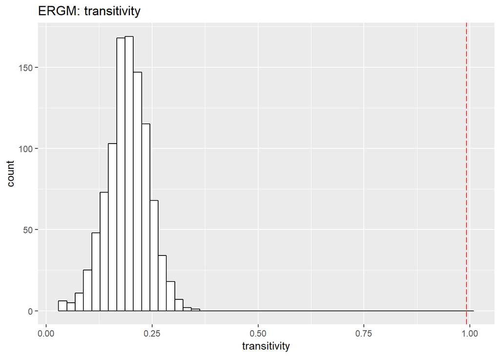

```r
ggplot() +
  aes(g_random_transitivity)+
  geom_histogram(bins = 50, colour="black", fill="white")+
  geom_vline(xintercept = transitivity(rd_eu28), colour="red", linetype = "longdash")+
  labs(title = "ERGM: transitivity",
       x = "transitivity")
```

[^1]: 1: Theoretische und mathematische Hintergründe zu der Normalisierung von Netzwerkmaßen für bipartite Netzwerke findet man in Scott/Carrington: The SAGE Handbook of Social Network Analysis, 2011, S. 425f